# ARIMAX - Inflation Rate ~ Oil Price

### Dataset

Our approach uses three different datasets. The primary macroeconomic variable, the inflation rate, is complemented by external factors, namely the oil price and oil production. To facilitate a holistic analysis, we have merged these datasets into one.

**{r}**

```r
# Import dataset
df_inflation <- read_csv('../data/viz_inflation.csv')

# Rename columns
names(df_inflation) <- c('DATE', 'Value')

# Import dataset
df_oil_price_month <- read_csv('../data/df_oil_price_month.csv')

# Import dataset
df_oil_price_month <- read_csv('../data/df_oil_price_month.csv')

# Create Date
df_oil_price_month <- df_oil_price_month %>%
  mutate(date2 = make_date(year(date), month(date), 01))

# Import dataset
df_oil_production_us <- read_csv('../data/viz_us_oil_production.csv')

# Rename columns
names(df_oil_production_us) <- c('date', 'Value')

# Create Date
df_oil_production_us <- df_oil_production_us %>%
  mutate(date2 = make_date(year(date), month(date), 01))


# Check maximum starting date between datasets
if(min(df_inflation$DATE) >= min(df_oil_price_month$date))
{
    min_date <- min(df_inflation$DATE)
}else
    {
        min_date <-min(df_oil_price_month$date)
    }

# Check maximum starting date between datasets
if(min_date >= min(df_oil_price_month$date))
{
    min_date <- min_date
}else
    {
        min_date <-min(df_oil_production_us$date)
    }

# Keep relevant columns
df_oil_price_month <- df_oil_price_month %>% dplyr::select('date2', 'adjusted')

# Keep relevant columns
df_oil_production_us <- df_oil_production_us %>% dplyr::select('date2', 'Value')

# Rename columns
names(df_inflation) <- c('DATE', 'inflation')

# Rename columns
names(df_oil_price_month) <- c('DATE', 'oil_price')

# Rename columns
names(df_oil_production_us) <- c('DATE', 'oil_production')

# Filter starting date
df_inflation <- df_inflation %>% filter(DATE >= min_date)

# Filter starting date
df_oil_price_month <- df_oil_price_month %>% filter(DATE >= min_date)

# Filter starting date
df_oil_production_us <- df_oil_production_us %>% filter(DATE >= min_date)

# Combine datasets
dd <- merge(df_inflation, df_oil_price_month, by.x = "DATE", by.y = "DATE", all = TRUE)

# Combine datasets
dd <- merge(dd, df_oil_production_us, by.x = "DATE", by.y = "DATE", all = TRUE)

# Order by Date sort ascending
dd <- dd %>% arrange(DATE)

# Create the time series object
dd.ts <- ts(dd,start=min_date,frequency = 12)

# Show table
knitr::kable(head(dd))
```

| DATE | inflation | oil_price | oil_production |
| --- | --- | --- | --- |
| 2000-09-01 | 3.454437 | 0.9740746 | 5758 |
| 2000-10-01 | 3.448276 | 1.0199688 | 5809 |
| 2000-11-01 | 3.446227 | 1.0546022 | 5833 |
| 2000-12-01 | 3.386809 | 0.8429909 | 5855 |
| 2001-01-01 | 3.732228 | 0.8954759 | 5799 |
| 2001-02-01 | 3.533569 | 0.8555382 | 5780 |

### Plot

The next important step is to visualize the original data. The graph below provides a separate axis for each variable considered, facilitating a comprehensive understanding of their individual patterns. The first insight we obtain is the difference in units. For this reason we need to transform the *oil production* variable.

**{r}**

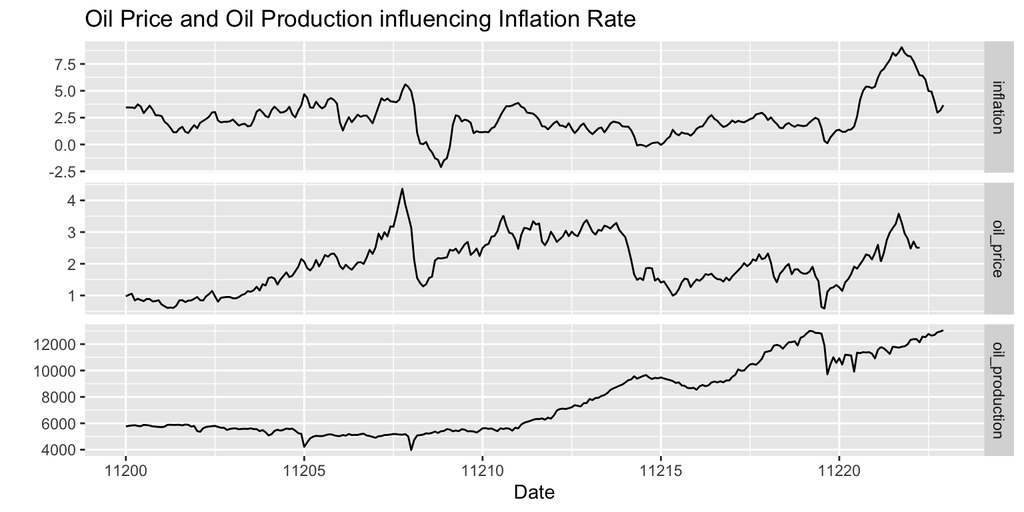

```r
# Plot time series for both variables.
autoplot(dd.ts[,c(2:4)], facets=TRUE) +
  xlab("Date") + ylab("") +
  ggtitle("Oil Price and Oil Production influencing Inflation Rate")
```

### Linear Model

As we continue our time series analysis, a critical step is to test the transformation of the oil production variable. Upon examination, we notice a significant change in the significance level within the general linear model, rendering the variable insignificant. As a result, we decide to keep the variable in its original form. We also decide to use a general linear model, recognizing the absence of a presumed linearity among the variables analyzed.

To assess the performance of this model, we examine the autocorrelation function (ACF) and partial autocorrelation function (PACF) plots for the residuals time series. These plots prove to be informative, revealing pronounced autocorrelation over numerous lags.

**{r}**

```r
# Create ts for Bus Passengers
dd$inflation <- ts(dd$inflation, start=min_date,frequency = 12)

# Create ts for Oil Price
dd$oil_price <- ts(dd$oil_price, start=min_date,frequency = 12)

# Create ts for Oil Price
dd$oil_production <- ts(dd$oil_production, start=min_date,frequency = 12)

# Fit the linear model
fit.reg <- glm(inflation ~ oil_price + oil_production, data=dd)

summary(fit.reg)
```

```
Call:
glm(formula = inflation ~ oil_price + oil_production, data = dd)

Coefficients:
                Estimate Std. Error t value Pr(>|t|)
(Intercept)    9.486e-02  4.112e-01   0.231  0.81772
oil_price      7.753e-01  1.285e-01   6.032 5.41e-09 ***
oil_production 1.097e-04  4.017e-05   2.732  0.00671 **
---
Signif. codes:  0 '***' 0.001 '**' 0.01 '*' 0.05 '.' 0.1 ' ' 1

(Dispersion parameter for gaussian family taken to be 2.854716)

    Null deviance: 881.65  on 267  degrees of freedom
Residual deviance: 756.50  on 265  degrees of freedom
  (8 observations deleted due to missingness)
AIC: 1046.7

Number of Fisher Scoring iterations: 2
```

### Autocorrelation Plots

**{r}**

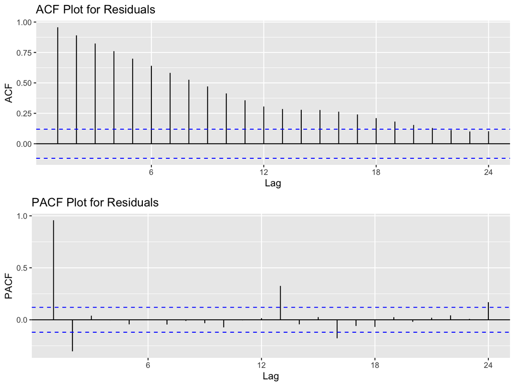

```r
res.fit <- ts(residuals(fit.reg),star=decimal_date(min_date),frequency = 12)

# ACF Plot
acf_plot <- ggAcf(res.fit, main="ACF Plot for Residuals")

# PACF Plot
pacf_plot <- ggPacf(res.fit, main="PACF Plot for Residuals")

# Arrange Plots
grid.arrange(acf_plot, pacf_plot, nrow=2)
```

### Differencing

The ACF plot provides a clear visual indication of high autocorrelation over most of the lags plotted. Recognizing the need for stationarity, the next critical step in our analysis is to perform differencing on the data. This process is performed to mitigate the observed autocorrelation patterns.

**First Ordinary Difference**

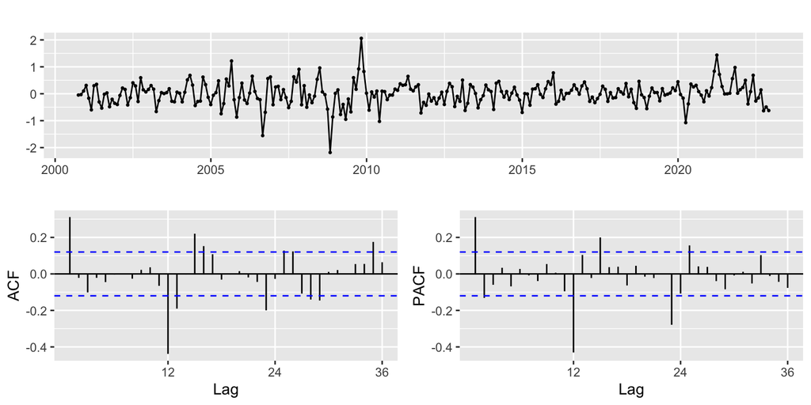

```r
# Ordinary Differencing
res.fit %>% diff() %>% ggtsdisplay()
```

### Model Parameters

By analyzing the ACF and PACF plots, we identified the following parameters for testing different time series models:

$d = 1$

**Parameters**

**{r}**

```r
xt <- res.fit

# PACF plot parameter selection
p_value <- 3

# Number of differences
d_value <- 2

# ACF plot parameter selection
q_value <- 3

# Initialize variable
i <- 1

# Initialize variable
temp <- data.frame()

# Calculate number of rows
rows <- p_value*d_value*q_value

#
ls <- matrix(rep(NA,6*rows),nrow=rows)

# Parameter testing loop
for (p in 1:p_value+1)
{
  for(q in 1:q_value+1)
  {
    for(d in 1:d_value)
    {

      #if(p-1+d+q-1<=8) #usual threshold
      #{

        model<- Arima(xt,order=c(p-1,d-1,q-1),include.drift=TRUE)
        ls[i,]= c(p-1,d-1,q-1,model$aic,model$bic,model$aicc)
        i=i+1
        #print(i)

      #}

    }
  }
}

temp <- as.data.frame(ls)

names(temp) <- c("p","d","q","AIC","BIC","AICc")

#temp
#knitr::kable(temp)
```

**{r}**

```r
# Check best model with AIC
temp[which.min(temp$AIC),]
```

```
   p d q      AIC      BIC     AICc
17 3 0 3 287.4815 319.8004 288.1792
```

**{r}**

```r
# Check best model with BIC
temp[which.min(temp$BIC),]
```

```
  p d q      AIC      BIC     AICc
2 1 1 1 295.5292 309.8782 295.6819
```

**{r}**

```r
# Check best model with AICc
temp[which.min(temp$AICc),]
```

```
   p d q      AIC      BIC     AICc
17 3 0 3 287.4815 319.8004 288.1792
```

**auto.arima()**

**{r}**

```r
# Assign the exogenous variable
xreg <- dd.ts[,c(3:4)]

fit_auto_arima <- auto.arima(dd.ts[, "inflation"], xreg = xreg)

summary(fit_auto_arima)
```

```
Series: dd.ts[, "inflation"]
Regression with ARIMA(1,1,0)(2,0,0)[12] errors

Coefficients:
         ar1     sar1     sar2  oil_price  oil_production
      0.4410  -0.6947  -0.3860     0.1691           1e-04
s.e.  0.0574   0.0583   0.0589     0.0961           1e-04

sigma^2 = 0.1064:  log likelihood = -85.04
AIC=182.08   AICc=182.4   BIC=203.6

Training set error measures:
                     ME     RMSE       MAE       MPE     MAPE      MASE
Training set 0.00685751 0.327434 0.2513836 0.7398985 34.10187 0.1534552
                  ACF1
Training set 0.0655825
```

### Model Diagnostics

The evaluation of the model selection criteria shows a consistent preference for the (3,0,3) model by AIC and AICc, while BIC was found to minimize the (1,1,1) model.

**AIC**

**Model Diagnostics - parameters with best AIC**

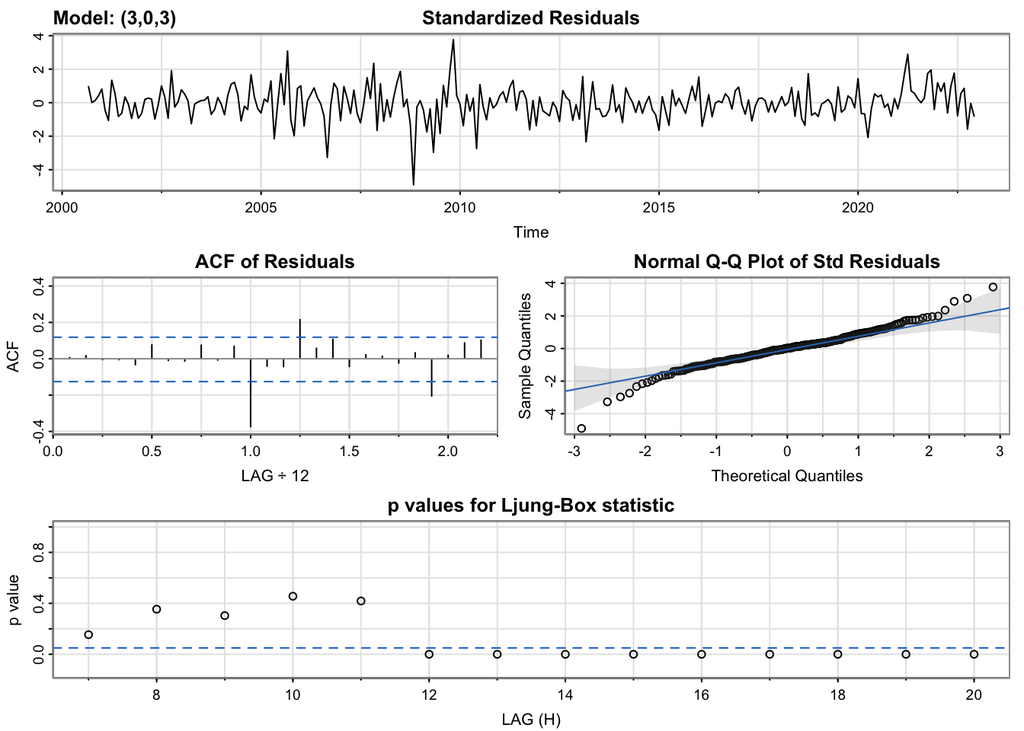

```r
AIC <- temp[which.min(temp$AIC),]

p1 <- AIC$p
d1 <- AIC$d
q1 <- AIC$q

# Model diagnostics for best AIC
model_output <- capture.output(sarima(xt, p1, d1, q1))
```

**BIC**

**Model Diagnostics - parameters with best BIC**

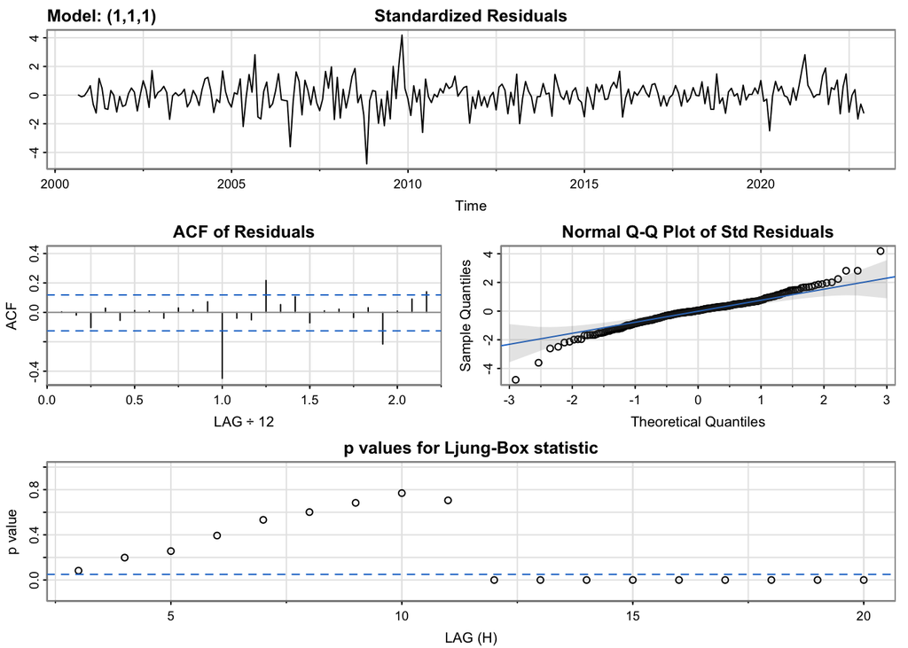

```r
BIC <- temp[which.min(temp$BIC),]

p2 <- BIC$p
d2 <- BIC$d
q2 <- BIC$q

# Model diagnostics for best BIC
model_output <- capture.output(sarima(xt, p2, d2, q2))
```

### Fit Model

We can observe that there should be an accurate predictive model by observing the fit model.

**Model Fit Plot**

**Model Fitting**

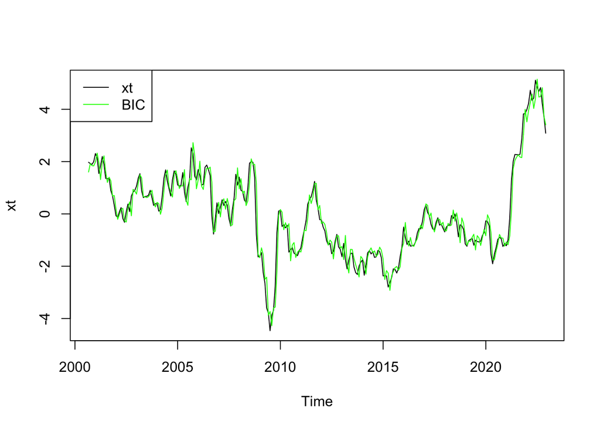

```r
best_model <- temp[which.min(temp$AIC),]

p <- best_model$p
d <- best_model$d
q <- best_model$q


model <- Arima(xt,order=c(p, d, q),include.drift = TRUE)

plot(xt, col="black")
lines(fitted(model), col="green")
legend(x = "topleft", legend = c("xt", "BIC"), col = c("black", "green"), lty = 1)
```

**Model Summary**

**Fitted Model Summary**

```r
fit <- Arima(xt, order=c(p, d, q))
summary(fit)
```

```
Series: xt
ARIMA(3,0,3) with non-zero mean

Coefficients:
         ar1     ar2     ar3     ma1     ma2     ma3    mean
      0.0644  0.0014  0.7944  1.2841  1.2644  0.2823  0.2990
s.e.  0.0637  0.0527  0.0482  0.0856  0.0862  0.0758  0.6302

sigma^2 = 0.1613:  log likelihood = -134.74
AIC=285.48   AICc=286.04   BIC=314.21

Training set error measures:
                       ME      RMSE       MAE       MPE     MAPE      MASE
Training set -0.007104327 0.3963572 0.2895371 -24.58156 86.80014 0.2261923
                    ACF1
Training set 0.006852081
```

### Forecast

The final version of the model is an ARIMA (3, 0, 3) model, which indicates that future inflation rates will tend to fall.

**{r}**

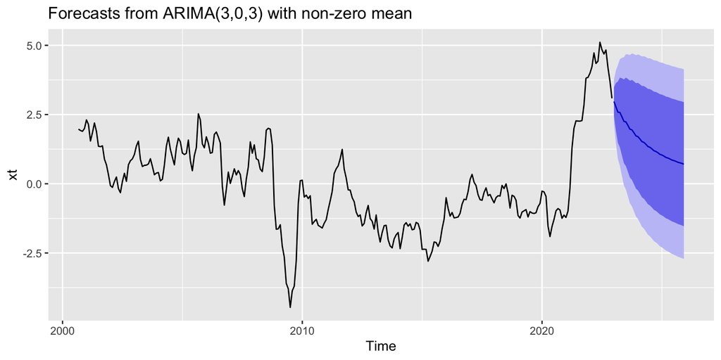

```r
forecast_fit <- forecast(fit,36)

# Path to save plot
file_path <- "../images/7_inflation.png"

# Plot
plot <- autoplot(forecast_fit)

# Use ggsave to save the plot as a PNG image
ggsave(plot, filename = file_path, width = 10, height = 5)

# Show plot
plot
```

### Benchmark Models

**Benchmark Models Plot**

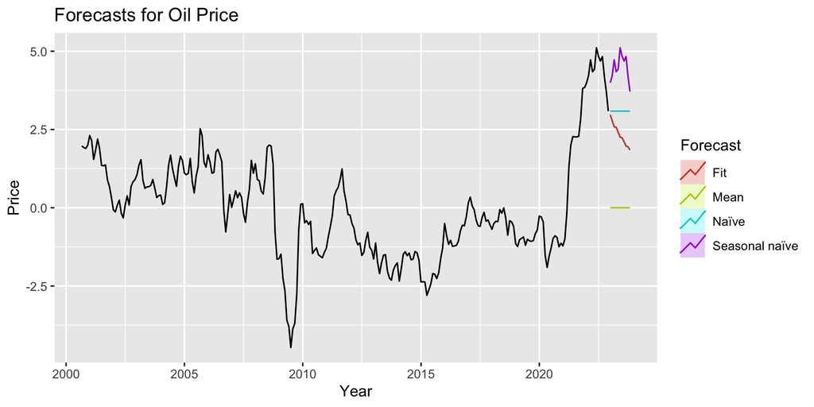

```r
autoplot(xt) +
  autolayer(meanf(xt, h=11),
            series="Mean", PI=FALSE) +
  autolayer(naive(xt, h=11),
            series="Naïve", PI=FALSE) +
  autolayer(snaive(xt, h=11),
            series="Seasonal naïve", PI=FALSE) +
  autolayer(forecast(forecast_fit, h=11),
            series="Fit", PI=FALSE) +
  ggtitle("Forecasts for Oil Price") +
  xlab("Year") + ylab("Price") +
  guides(colour=guide_legend(title="Forecast"))
```